# PS5: Intro to `ggplot2`

## 2.3 Settings -vs- Mappings

In the Grammar of Graphics, it is important to understand the difference between a *mapping* and a *setting*. Recall that a **setting** is when you set or fix the value of a visual attribute to a constant or a value that does NOT come from the data frame. Write commands that use settings to create the following graphics.

1. Histogram of `Sepal.Length`, filling the bars in `"orange"` (fill) and changing the color of the bar borders to `"white"` (color).

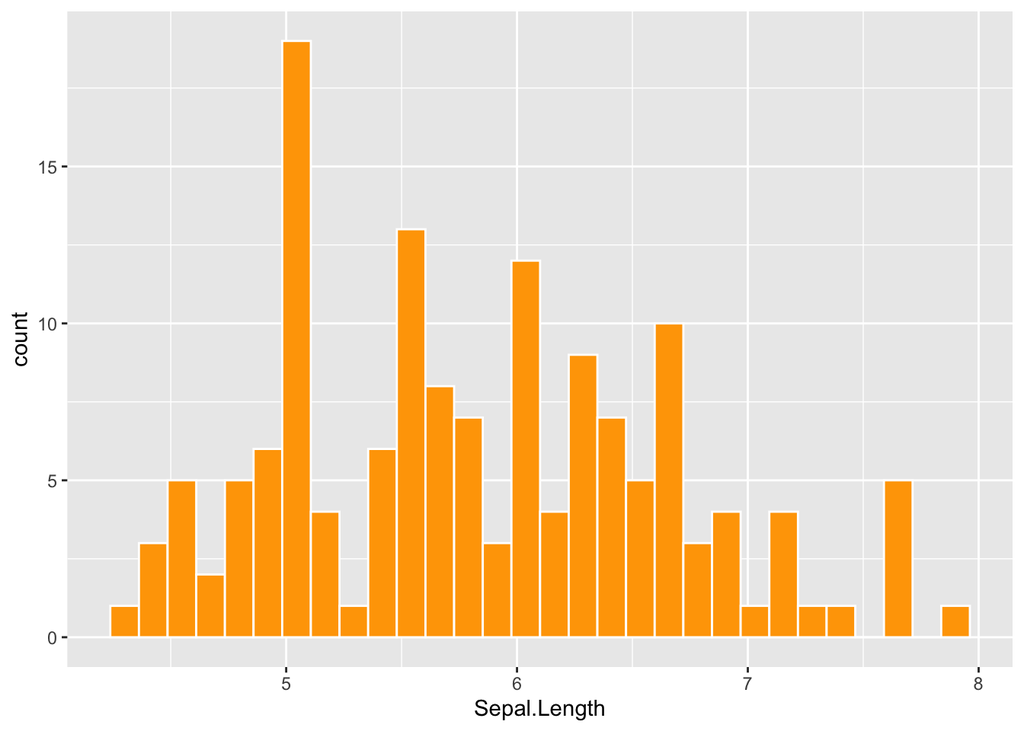

```r
# your code here
ggplot(data = iris, mapping = aes(x = Sepal.Length)) + geom_histogram(fill = "orange", color = "white")
```

2. Scatter plot of `Sepal.Length` (x) and `Sepal.Width` (y) coloring points in `"red"` (color), change size of points to 3 (size).

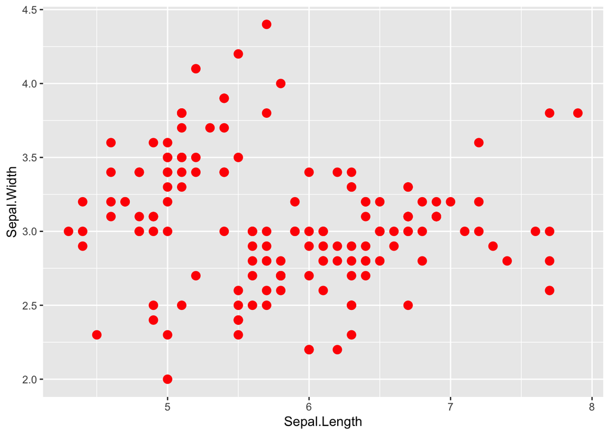

```r
# your code here
ggplot(data = iris, mapping = aes(x = Sepal.Length, y = Sepal.Width)) + geom_point(color = "red", size = 3)
```

3. Bar plot of `Species` from a random sample of 40 flowers filling color of bars to “turquoise.”

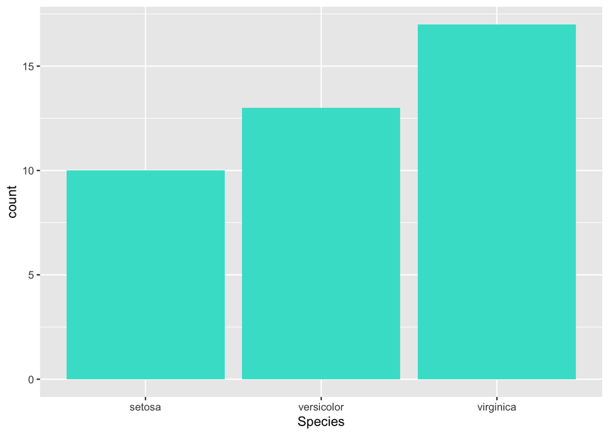

```r
# your code here
iris %>%
  slice_sample(n = 40) %>%
  ggplot(mapping = aes(x = Species)) +
  geom_bar(fill = "turquoise")
```

## 2.4 Labels, Annotations and Themes

1. Choose two numerical variables from `iris` and graph a scatter plot, **set the color of points** to `"blue"`, and add the following:
   - title
   - x-axis label
   - y-axis label

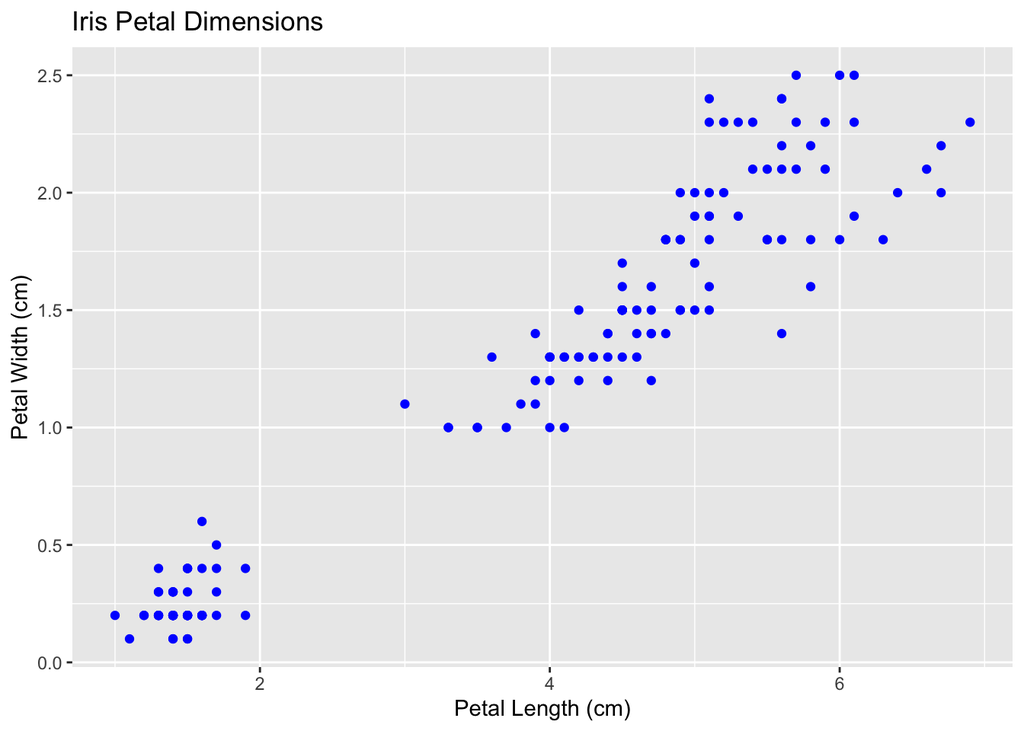

```r
# your code here
ggplot(iris, aes(x = Petal.Length, y = Petal.Width)) +
  geom_point(color = "blue") +
  labs(title = "Iris Petal Dimensions",
       x = "Petal Length (cm)",
       y = "Petal Width (cm)")
```

2. Choose a different pair of numerical variables from `iris` and graph another scatter plot, color coding points by `Species`, and add a text annotation to highlight something interesting or unusual in the plot. Your plot should still include a title, x-axis label, and y-axis label.

```r
# your code here
ggplot(iris, aes(x = Sepal.Length, y = Petal.Length, color = Species)) +
  geom_point() +
  annotate("text", x = 5, y = 3, label = "Setosa cluster is distinct", color = "darkred", fontface = "italic") +
  labs(title = "Sepal vs Petal Length by Species",
       x = "Sepal Length",
       y = "Petal Length")
```

[output not shown]

3. Choose one of your previous two scatter plots and re-graph it but this time using a ggplot **theme** that is different from the default one. Your plot should still include a title, x-axis label, and y-axis label.

```r
# your code here
ggplot(iris, aes(x = Petal.Length, y = Petal.Width)) +
  geom_point(color = "blue") +
  theme_minimal() +
  labs(title = "Iris Petal Dimensions (Minimal Theme)",
       x = "Petal Length (cm)",
       y = "Petal Width (cm)")
```

[output not shown]

## 2.5 More Questions

1. Are the following lines of code equivalent (i.e. give you the same plot)? If not, explain why.

```r
ggplot(iris, aes(x = Petal.Length, y = Petal.Width, color = Species)) +
  geom_point()

ggplot(iris, aes(x = Petal.Length, y = Petal.Width)) +
  geom_point(aes(color = Species))
```

**NoteYour Answer Here**

Yes, they are equivalent. In the first line, the mapping is defined globally in `ggplot()`, meaning all subsequent layers inherit it. In the second line, the mapping is defined locally within `geom_point()`. Since there is only one layer, the resulting plot is identical.

2. Are the following lines of code equivalent (i.e. give you the same plot)? If not, explain why.

```r
ggplot(iris, aes(Petal.Length, Petal.Width)) +
  geom_point(color = "blue")

ggplot(iris, aes(Petal.Length, Petal.Width, color = "blue")) +
  geom_point()
```

**NoteYour Answer Here**

No, they are not. The first line **sets** the color to blue, so all points will be blue. The second line maps the string “blue” as a variable. Because it is inside `aes()`, ggplot looks for a variable named “blue” (finds none) and assigns it the default color.

3. Are the following lines of code equivalent?

```r
ggplot(iris, aes(Petal.Length, Petal.Width)) +
  geom_point()

ggplot(iris) +
  geom_point(aes(Petal.Length, Petal.Width))
```

**NoteYour Answer Here**

Yes. The first maps the variables globally, while the second maps them locally within the geom. Both will produce a standard scatter plot of the same variables.

4. What is the problem with the following code? How can it be fixed?

```r
# scatter plot of Petal.Width, and Petal.Length
ggplot(iris) +
  geom_point(x = Petal.Width, y = Petal.Length)
```

**NoteYour Answer Here**

Missing `aes()` function. Fix: `ggplot(iris) + geom_point(aes(x = Petal.Width, y = Petal.Length))`

5. What is the problem with the following code? How can it be fixed?

```r
# scatter plot of Petal.Width, and Petal.Length
ggplot(iris, aes(Petal.Length, Petal.Width))
  geom_point(aes(color = Species))
```

**NoteYour Answer Here**

Missing `+` sign at the end of the first line. Fix: `ggplot(iris, aes(Petal.Length, Petal.Width)) + geom_point(aes(color = Species))`

6. What is the problem with the following code? How can it be fixed?

```r
# scatter plot of Petal.Width, and Petal.Length
ggplot(iris, aes(x = Petal.Length  y = Petal.Width)) +
  goem_point(aes(color = Species))
```

**NoteYour Answer Here**

Missing `,` comma between `x` and `y`, and `goem_point` is misspelled.